# Applications of order statistics

## This week in tgs data science

Urinary incontinence and physical activity

## Review

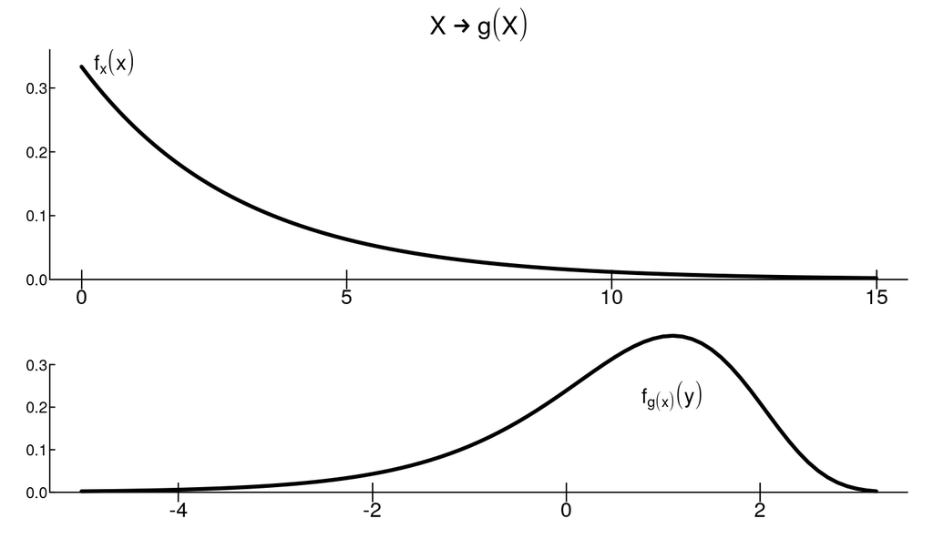

## Review

What is the distribution of an outcome after transformation? \[\text{If } X\sim F_X(x), \text{ then } g(X) \sim ??\]

## Review

What is the distribution of a transformation of a sample? \[\text{If } X_i\sim F_X(x), \text{ then } g(X_1, X_2, \cdots, X_n) \sim ??\]

## Review

Specifically, we have looked at quantiles \[\text{If } X_i\sim F_X(x), \text{ then } \text{median}(X_1, X_2, \cdots, X_n) \sim F_{((N+1)/2)}\]

Recall \(F_{(k)}\) is the CDF for the \(k^{th}\) order statistic.

## Applications

## Sequential system

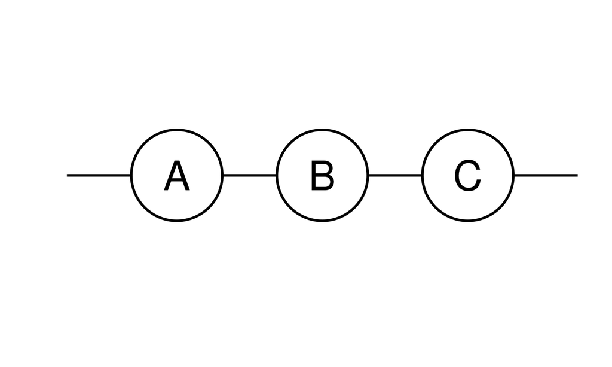

## Sequential system

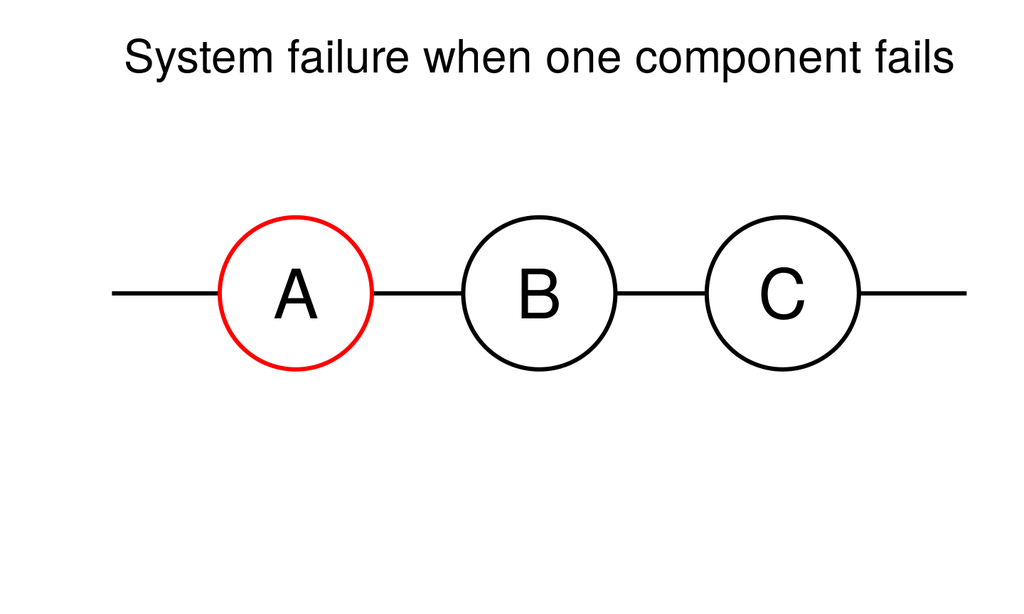

## Parallel system

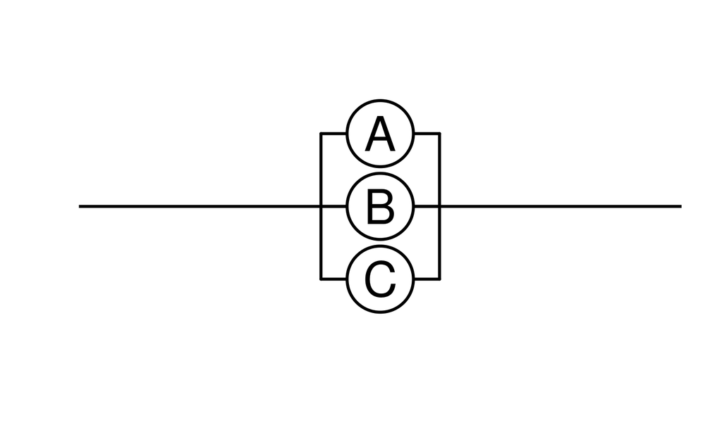

## Parallel system

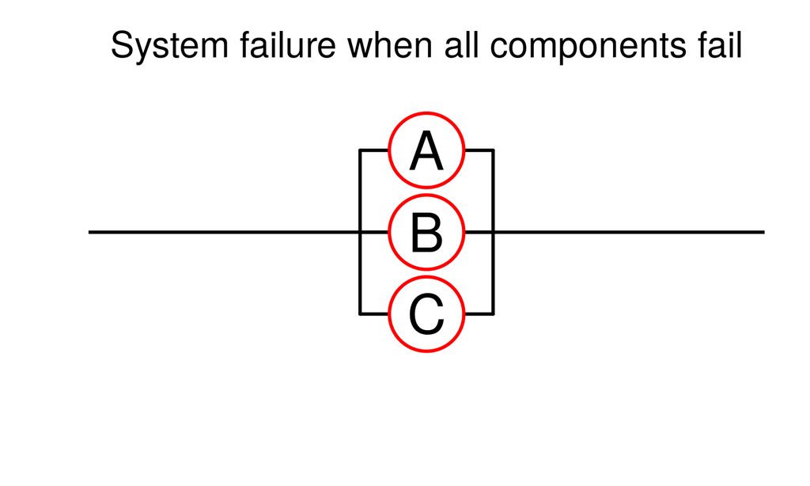

## Compare the sequential system vs the parallel system

Suppose the components have a failure time distribution

\[\text{time to component failure} \sim \text{weibull}(\text{shape} = 1.3, \text{scale} = 2) \]

## Compare the sequential system vs the parallel system

Suppose the components have a failure time distribution

\[\text{time to component failure} \sim \text{weibull}(\text{shape} = 1.3, \text{scale} = 2) \]

What is the **time to system failure** for the sequential system?

What is the **time to system failure** for the parallel system?

## Group work

1. Simulate **time to system failure** for both systems.
2. Generate a plot that shows the histogram and analytical density of **time to system failure** for sequential and parallel systems.
3. Generate a plot that shows the ECDF and analytical CDF of **time to system failure** for sequential and parallel systems.
4. Post your figures to the course Slack page.

## The sample mean when E[X] does not exist

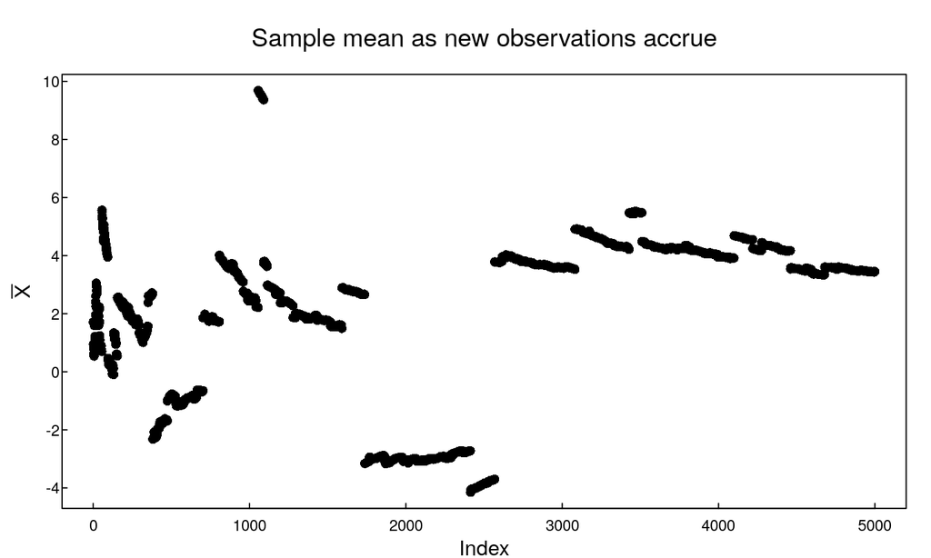

## The sample median when E[X] does not exist

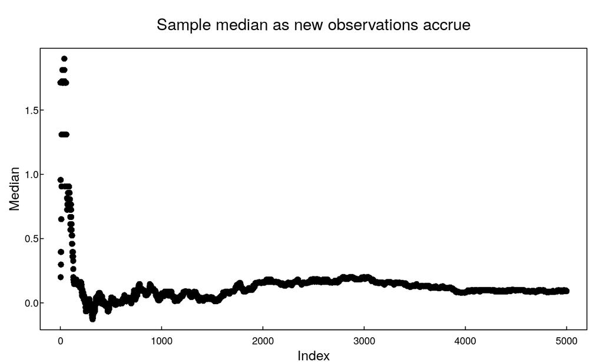

## The sample median or mean when E[X] does not exist

If \(E[X]\) does not exist, a reasonable target of inference is the median.